# Titanic: Survival Prediction

### Age

Transforming ages into groups

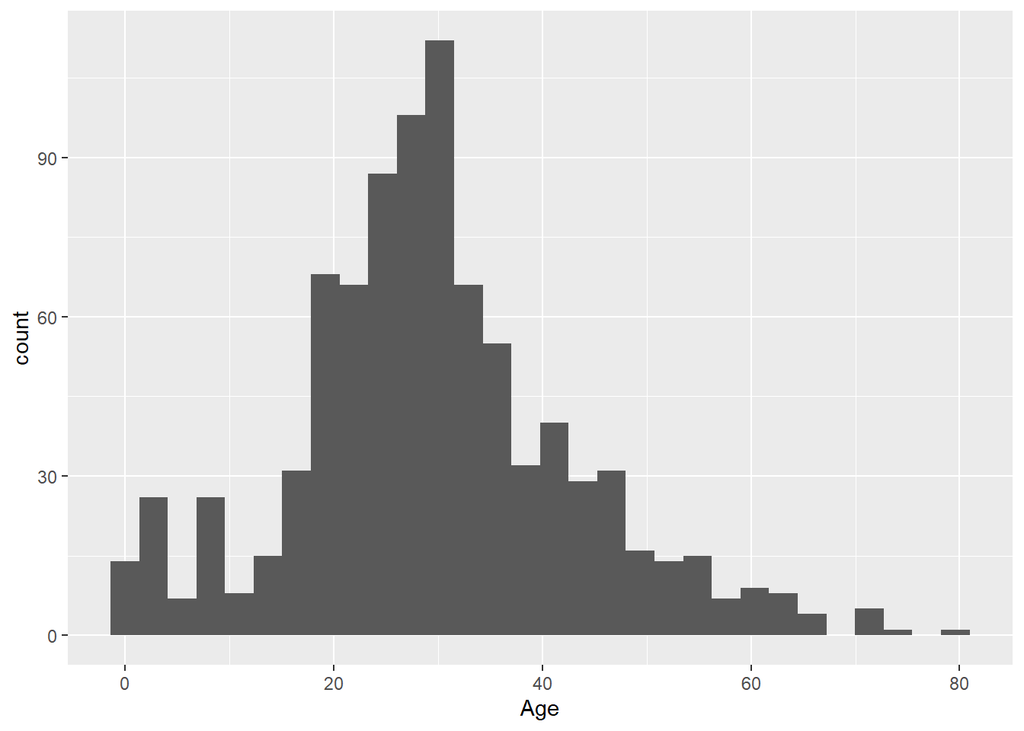

```r
ggplot(titanic[1:891,], aes(Age)) +
        geom_histogram(bins=30)
```

```r
titanic <- titanic %>%
        mutate(AgeGrp = factor( case_when(
                between(Age, 0, 16) ~ "young",
                between(Age, 16, 50) ~ "adult",
                Age > 50 ~ "old")))

titanic %>%
        count(AgeGrp)
```

```
## # A tibble: 3 x 2
##   AgeGrp     n
##   <fct>  <int>
## 1 adult   1066
## 2 old       95
## 3 young    148
```

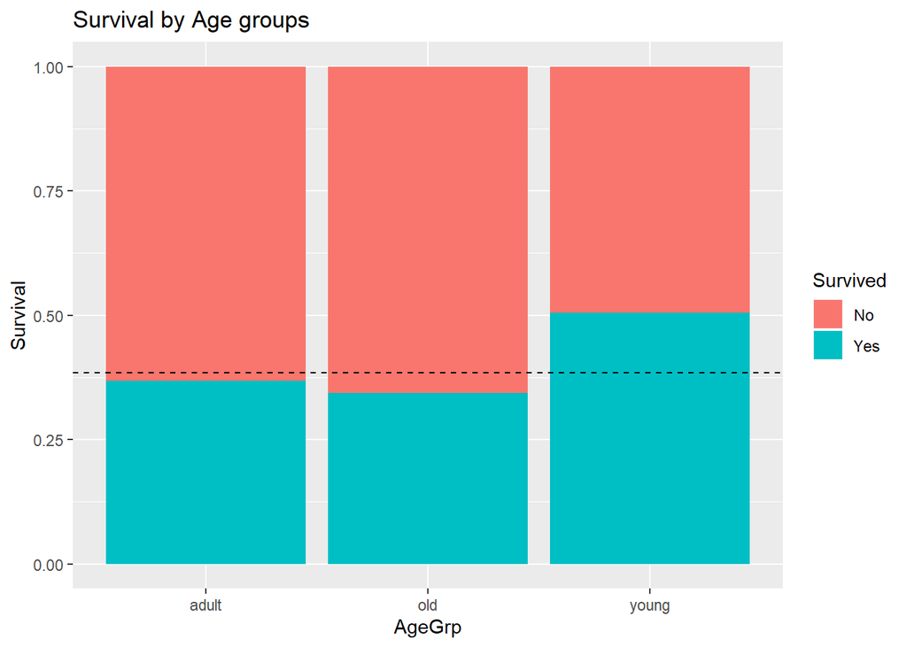

```r
ggplot(titanic[1:891,], aes(x = AgeGrp, fill = Survived)) +
        geom_bar(position = "fill") +
        ylab("Survival") +
        geom_hline(yintercept = (sum(train$Survived)/nrow(train)), col = "black", lty = 2) +
        ggtitle("Survival by Age groups")
```

Only age group “young” are above the survival rate line.

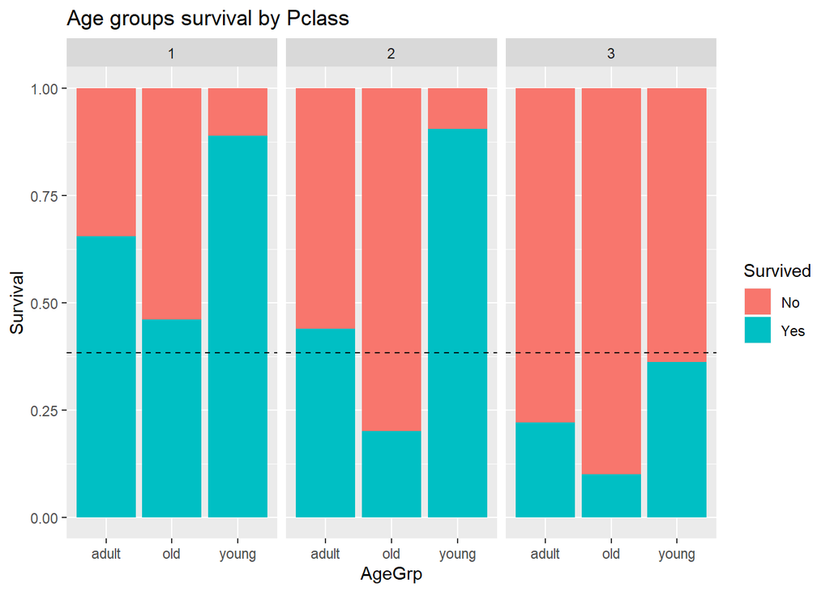

```r
ggplot(titanic[1:891,], aes(AgeGrp, fill=Survived)) +
        geom_bar(position = "fill") +
        ylab("Survival") +
        geom_hline(yintercept = (sum(train$Survived)/nrow(train)), col = "black", lty = 2) +
        ggtitle("Age groups survival by Pclass") + facet_wrap(~ Pclass)
```

Only 3rd class passengers are under the survival rate line in all age groups.

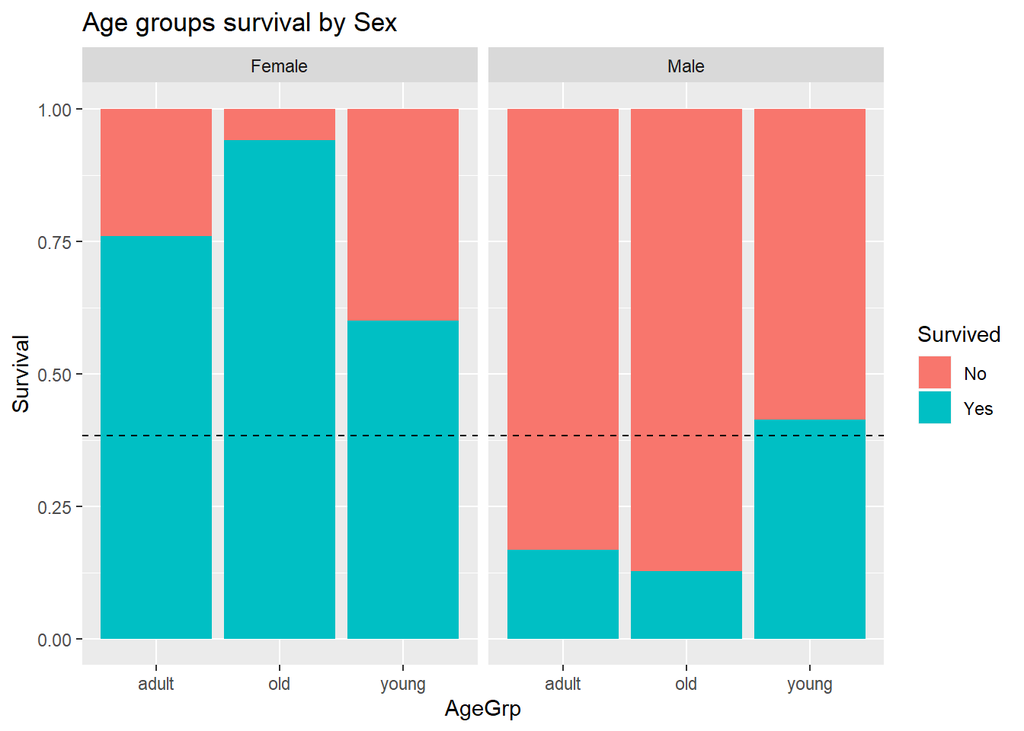

```r
ggplot(titanic[1:891,], aes(AgeGrp, fill=Survived)) +
        geom_bar(position = "fill") +
        ylab("Survival") +
        geom_hline(yintercept = (sum(train$Survived)/nrow(train)), col = "black", lty = 2) +
        ggtitle("Age groups survival by Sex") + facet_wrap(~ Sex)
```

Only man from age group “adult” and “old” are under the survival rate line

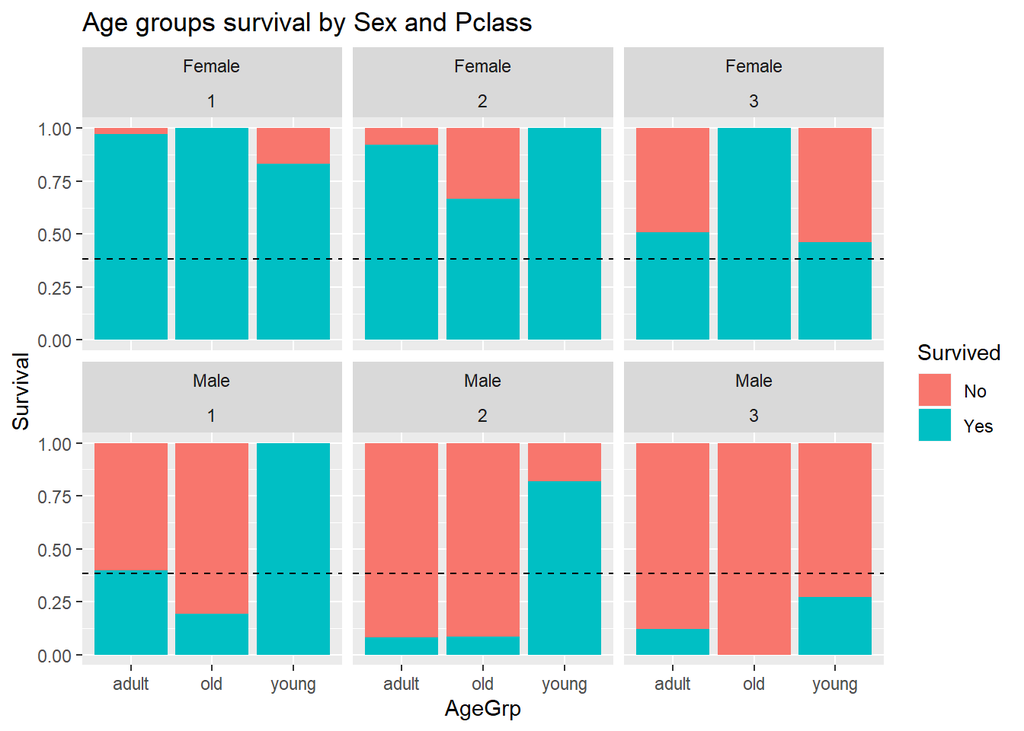

```r
ggplot(titanic[1:891,], aes(AgeGrp, fill=Survived)) +
        geom_bar(position = "fill") +
        ylab("Survival") +
        geom_hline(yintercept = (sum(train$Survived)/nrow(train)), col = "black", lty = 2) +
        ggtitle("Age groups survival by Sex and Pclass") + facet_wrap(~ Sex*Pclass)
```

The female are above the survival rate line in all age groups and passenger class. Only the young and adult male from 1st class and the young male from 2nd class are above that line.

## Predict using random forest

### Split into training and test sets

```r
train1 <- titanic[1:891,]
test1 <- titanic[892:1309,]
```

### Building the model

```r
library(party)
set.seed(456)
titanic_model <- cforest(Survived ~
                            Sex +
                            Title +
                            FamilySize +
                            FareGrp +
                            Pclass +
                            AgeGrp +
                            Embarked,
                    data = train1,
                    controls = cforest_unbiased(ntree = 2000, mtry = 3))
```

The confusion matrix shows how many predictions were correct for died or survived category

```r
ptable <- table(predict(titanic_model), train1$Survived)

library(caret)

confusionMatrix(ptable)
```

```
## Confusion Matrix and Statistics
##
##
##        No Yes
##   No  509  99
##   Yes  40 243
##
##                Accuracy : 0.844
##                  95% CI : (0.8185, 0.8672)
##     No Information Rate : 0.6162
##     P-Value [Acc > NIR] : < 2.2e-16
##
##                   Kappa : 0.6591
##
##  Mcnemar's Test P-Value : 8.677e-07
##
##             Sensitivity : 0.9271
##             Specificity : 0.7105
##          Pos Pred Value : 0.8372
##          Neg Pred Value : 0.8587
##              Prevalence : 0.6162
##          Detection Rate : 0.5713
##    Detection Prevalence : 0.6824
##       Balanced Accuracy : 0.8188
##
##        'Positive' Class : No
##
```

Now let’s see which variables are perceived as most important by the model

```r
varimp(titanic_model)
```

```
##          Sex        Title   FamilySize      FareGrp       Pclass       AgeGrp
## 0.0736773700 0.1362461774 0.0290626911 0.0005856269 0.0411284404 0.0070932722
##     Embarked
## 0.0074571865
```

we can see that Title and Sex are by far the most important variables according to the model.

let’s make the predictions and submit to Kaggle

```r
tm.pred <- predict(titanic_model, newdata = test1, OOB=TRUE, type = "response")
tm.pred <- ifelse(tm.pred == "No", 0, 1)
tm.output <- data.frame(PassengerID = test1$PassengerId, Survived = tm.pred)
# Write the Output to file:
# write.csv(tm.output, file = 'titanic_model.csv', row.names = F)
```